# Лабораторная работа №11

Программирование в командном процессоре ОС UNIX. Ветвления и циклы

Ежова А. М.

Российский университет дружбы народов, Москва, Россия

Факультет физико-математических и естесвенных наук

19 апреля 2023

# Информация

## Докладчик

- Ежова Алиса Михайловна
- студентка НБИбд-01-22
- Российский университет дружбы народов
- https://github.com/AlisaEzhova

[figure not shown]

# Вводная часть

## Цели и задачи

- Изучить основы программирования в оболочке ОС UNIX. Научится писать более сложные командные файлы с использованием логических управляющих конструкций и циклов

## Материалы и методы

- Процессор `pandoc` для входного формата Markdown
- Результирующие форматы
  - `pdf`
  - `html`
- Автоматизация процесса создания: `Makefile`

# Создание презентации

## Процессор `pandoc`

- Pandoc: преобразователь текстовых файлов
- Сайт: https://pandoc.org/
- Репозиторий: https://github.com/jgm/pandoc

## Формат `pdf`

- Использование LaTeX
- Пакет для презентации: beamer
- Тема оформления: `metropolis`

## Код для формата `pdf`

```yaml
slide_level: 2
aspectratio: 169
section-titles: true
theme: metropolis
```

## Формат `html`

- Используется фреймворк [reveal.js](https://revealjs.com/)
- Используется [тема](https://revealjs.com/themes/) `beige`

## Код для формата `html`

- Тема задаётся в файле `Makefile`

```
REVEALJS_THEME = beige
```

# Результаты

## Получающиеся форматы

- Полученный `pdf`-файл можно демонстрировать в любой программе просмотра `pdf`
- Полученный `html`-файл содержит в себе все ресурсы: изображения, css, скрипты

## Содержание исследования

1. Используя команды getopts grep, написала командный файл, который анализирует командную строку с ключами: – -iinputfile — прочитать данные из указанного файла; – -ooutputfile — вывести данные в указанный файл; – -pшаблон — указать шаблон для поиска; – -C — различать большие и малые буквы; – -n — выдавать номера строк. а затем ищет в указанном файле файле нужные строки, определяемые ключом -p:

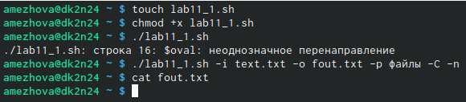

Код

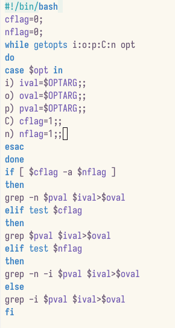

Код 2

#!/bin/bash gcc -c script2.c gcc -o script2 script2.c ./script2 case $? in 1) echo отрицательное;; 2) echo равно нулю;; 3) echo положительное;; esac

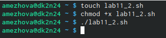

Код 3

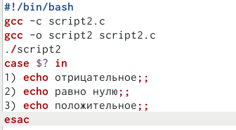

Код 4

3. Написала командный файл, создающий указанное число файлов, пронумерованных последовательно от 1 до N:

#!/bin/bash let i=$1+1 while (( i-=1 )) do touch $i.tmp done let j=$2+1; while (( j-=1 )) do rm $j.tmp done

4. Написала командный файл, который с помощью команды tar запаковывает в архив все файлы в указанной директории. Модифицировала его так, чтобы запаковывались только те файлы, которые были изменены менее недели тому назад.

#!/bin/bash (find $1 -mtime -7 -daystart) | xargs tar -cf arhiv.tar

## Итоговый слайд

- В ходе выполнения Лабораторной работы №11, я изучила основы программирования в оболочке ОС UNIX. Научилась писать более сложные командные файлы с использованием логических управляющих конструкций и циклов.